# assignmentastro

Blackhole! The term is quite fascinating in and of itself. There might be hardly a person who doesn’t get overwhelmed with the idea of it. But why do people love blackholes so much? Because…... I don’t know, there might be a reason behind it, we are not getting into it now, we are gonna talk about stars now, not ordinary stars, we are gonna talk about the stars that revolve around black holes. So what do you think? What Does the trajectory look like of those stellar objects? I know you don’t know. I didn’t know either. Anyways, let me show you the trajectory in 2D plotted in polar coordinates. The trajectory looks like this-

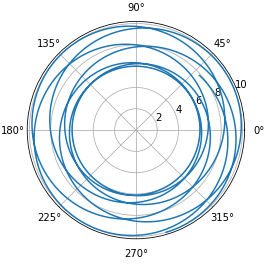

But, it is not the only trajectory; rather it is one of many different trajectories, the trajectory depends on the initial values you set for the variables of the distinct equations. Now that we have got an idea about how the trajectory of the stellar objects looks, let’s see whether we can create a simulation of the motion of stellar objects around a black hole. So, for this objective, we are gonna use 4 ODE’s (ordinary differential calculus) and we will solve them using Euler’s method. Here you go, the equations we will be using for our purpose are-

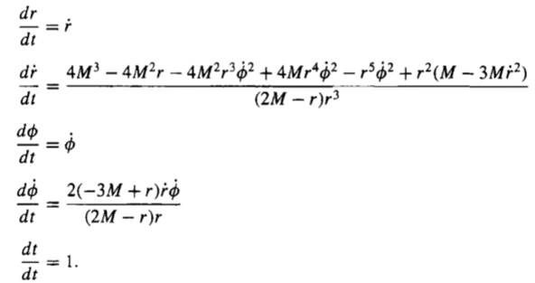

The equations seem dreadful right? Seemed to me at least. Even if it seems a bit daunting, the method we are gonna use is quite easy as well as accurate. Ok, let’s get into some boring parts now which will make the outcome so incredible. Let’s start then, by solving the ODE’s we will be able to get the values of r and phi. But why do we need these values? Because as we need to use the polar coordinates, in polar coordinates we determine the distance of an object in polar coordinates using r and phi, it is just as identical to how we utilize the x and y values in specifying the position of an object in x-y coordinates. Moreover, as we want to design the trajectory we will need several values of r and phi. Needing several values of r and phi means the positions of the stellar objects in different times or we can see this like this as well, the difference of the values of r and phi in proportion to time. enough about the theoretical part. So how are we gonna execute this? So, the programming language we are gonna use is python. Let the battle begin.

Here are the imports-

```python
import numpy as np
import matplotlib.pyplot as plt
import vpython as vp
```

Now defining the function that would solve the ODE’s for us and return or calculate a new array that will include the values of dr,ddr, dphi, ddphi. Stop! (that was a hard break though) So after running this function in the loop(the loop is in the following function) for the first time we will get the first new values of r and phi and constantly running the loop will repeatedly provide us with new values of r and phi and we will get to learn about different values of r and phi in different times and that’s how the trajectory is created.

```python
def f(data):
    M = 1
    r = data[0]
    dr = data[1]
    r1=dr
    phi=data[2]
    p=phi
    dphi = data[3]
    p1=dphi

    ddr = ((4 * M**3) - (4 * M**2 * r) - (4 * M**2 * r**3 * p1**2) + (4 * M * r**4 * p1**2) - (r**5 * p1**2) + (r**2 * (M - 3 * M * r1**2))) / ((2 * M - r) * r**3)
    ddphi = (2 * (-3 * M + r) * r1 * p1) / ((2 * M - r) * r)

    return np.array([dr, ddr, dphi, ddphi], float)
```

Here are the arrays we will be using for the initial values of r,dr,phi,dphi-

```python
data = np.array([10,0,5,0.03], float)
data1= np.array([10.2,0,4,0.03], float)
data2= np.array([10.3,0,0,0.03], float)
data3= np.array([10.45,0,3,0.03], float)
data4= np.array([10.55,0,0,0.03], float)
data5=np.array([10.60,1,0,0.03], float)
data6=np.array([10.70,0,2,0.03], float)
data7=np.array([10.75,0,0,0.03], float)
data8= np.array([10.80,0,0,0.03], float)
data9 = np.array([11,0,6,0.03], float)
data10 = np.array([10.90,0.5,5,0.03], float)
data11 = np.array([10,0.5,5.5,0.03], float)
data12 = np.array([10,.8,5,0.1], float)
data13 = np.array([10,0.1,5,0.03], float)
data14 = np.array([10,0,5.75,0.03], float)
data15 = np.array([10,0.25,5,0.03], float)
data16 = np.array([10,0.4,5,0.03], float)
data17 = np.array([10.98,0.125,5,0.03], float)
data18 = np.array([10,0.45,5,0.03], float)
data19 = np.array([10.23,0.45,5,0.03], float)
data20 = np.array([10,0.2,5.01,0.035], float)
data21 = np.array([10,0.75,5.1,0.023], float)
data22 = np.array([10.05,0.9,5.8,0.33], float)
data23 = np.array([10.5,0.4,5.1,0.73], float)
data24 = np.array([10.06,0.45,5.78,0.73], float)
data25 = np.array([10.07,0.25,5.67,0.53], float)
data26 = np.array([10,1,5,0.03], float)
data27 = np.array([10,0,5,0.03], float)
data28 = np.array([10.1,0.1,5.1,0.03], float)
data29 = np.array([10.3,0.2,5,0.03], float)
data30 = np.array([10.2,0.4,5,0.03], float)
```

This function is needed so that the array(say data1) we defined gets changed every time in proportion to time. We have created 2 empty lists here radius and phi, these lists add every new value of r and phi to their list as the loop goes on. But we have got a situation here, we can't simulate the motion of a stellar object using the values of its in polar coordinates and so we are gonna convert the values to if they were in x,y coordinates., and "xs" and "ys" contain the values of r and phi in x,y coordinates.

```python
def trajectory(R):


    h = 0.01
    T = np.arange(0,1000, h)
    radius = []
    phi = []
    for t in T:
        radius.append(R[0])
        phi.append(R[2])
        R = R + h * f(R)
    xs = radius*np.cos(phi)
    ys = radius*np.sin(phi)
    return xs, ys
```

Graph of trajectory in x,y coordinates.

```python
xs=(trajectory(data))[0]
ys=(trajectory(data))[1]

plt.plot(xs,ys)
plt.show()
```

[output not shown]

The prior part was a daunting part of our life, theory blah….Let’s try to forget it(let bygones be bygones) and to remove the memory of this dark phase we are gonna do the simulation now using vpython.

So, we need to create a freezing, dark space to keep our black hole and stellar objects for that we are using the “canvas()” command.

```python
space = vp.canvas()
```

Moving on, we are gonna take the stellar objects as spheres and give them a radius and colour. Here we are calling our trajectory function and as the parameter, we are gonna give an initial array we defined earlier, and according to the initial array, we get different lists containing values of x and y.

```python
xs,ys=trajectory(data)
xs1,ys1=trajectory(data1)
xs2,ys2=trajectory(data2)
xs3,ys3=trajectory(data3)
xs4,ys4=trajectory(data4)
xs5,ys5=trajectory(data5)
xs6,ys6=trajectory(data6)
xs7,ys7=trajectory(data7)
xs8,ys8=trajectory(data8)
xs9,ys9=trajectory(data9)
xs10,ys10=trajectory(data10)
xs11,ys11=trajectory(data11)
xs12,ys12=trajectory(data12)
xs13,ys13=trajectory(data13)
xs14,ys14=trajectory(data14)
xs15,ys15=trajectory(data15)
xs16,ys16=trajectory(data16)
xs17,ys17=trajectory(data17)
xs18,ys18=trajectory(data18)
xs19,ys19=trajectory(data19)
xs20,ys20=trajectory(data20)
xs21,ys21=trajectory(data21)
xs22,ys22=trajectory(data22)
xs23,ys23=trajectory(data23)
xs24,ys24=trajectory(data24)
xs25,ys25=trajectory(data25)
xs26,ys26=trajectory(data26)
xs27,ys27=trajectory(data27)
xs28,ys28=trajectory(data28)
xs29,ys29=trajectory(data29)
xs30,ys30=trajectory(data30)




Black_Hole = vp.sphere(pos = vp.vector(0,0,0), radius = 0.5, color = vp.color.black, canvas = space)
object0 = vp.sphere(pos = vp.vector(xs[0],ys[0],0), radius = 0.3, color = vp.color.blue, canvas = space)


object1 = vp.sphere(pos = vp.vector(xs1[0],ys1[0],0), radius = 0.3, color = vp.color.yellow, canvas = space)
object2 = vp.sphere(pos = vp.vector(xs2[0],ys2[0],0), radius = 0.3, color = vp.color.cyan, canvas = space)

object3 = vp.sphere(pos = vp.vector(xs3[0],ys3[0],0), radius = 0.3, color = vp.color.green, canvas = space)

object4 = vp.sphere(pos = vp.vector(xs4[0],ys4[0],0), radius = 0.3, color = vp.color.cyan, canvas = space)

object5 = vp.sphere(pos = vp.vector(xs5[0],ys5[0],0), radius = 0.3, color = vp.color.magenta, canvas = space)
object6 = vp.sphere(pos = vp.vector(xs6[0],ys6[0],0), radius = 0.3, color = vp.color.white, canvas = space)
object7 = vp.sphere(pos = vp.vector(xs7[0],ys7[0],0), radius = 0.3, color = vp.color.blue, canvas = space)
object8 = vp.sphere(pos = vp.vector(xs8[0],ys8[0],0), radius = 0.3, color = vp.color.yellow, canvas = space)
object9 = vp.sphere(pos = vp.vector(xs9[0],ys9[0],0), radius = 0.3, color = vp.color.cyan, canvas = space)
object10= vp.sphere(pos = vp.vector(xs10[0],ys10[0],0),radius = 0.3,color = vp.color.blue, canvas = space)
object11 = vp.sphere(pos = vp.vector(xs11[0],ys11[0],0), radius = 0.3, color = vp.color.white, canvas = space)
object12 = vp.sphere(pos = vp.vector(xs12[0],ys12[0],0), radius = 0.3, color = vp.color.red, canvas = space)
object13 = vp.sphere(pos = vp.vector(xs13[0],ys13[0],0), radius = 0.3, color = vp.color.green, canvas = space)
object14 = vp.sphere(pos = vp.vector(xs14[0],ys14[0],0), radius = 0.3, color = vp.color.blue, canvas = space)
object15 = vp.sphere(pos = vp.vector(xs15[0],ys15[0],0), radius = 0.3, color = vp.color.cyan, canvas = space)
object16 = vp.sphere(pos = vp.vector(xs16[0],ys16[0],0), radius = 0.3, color = vp.color.magenta, canvas = space)
object17 = vp.sphere(pos = vp.vector(xs17[0],ys17[0],0), radius = 0.3, color = vp.color.green, canvas = space)
object18 = vp.sphere(pos = vp.vector(xs18[0],ys18[0],0), radius = 0.3, color = vp.color.red, canvas = space)
object19 = vp.sphere(pos = vp.vector(xs19[0],ys19[0],0), radius = 0.3, color = vp.color.magenta, canvas = space)
object20 = vp.sphere(pos = vp.vector(xs20[0],ys20[0],0), radius = 0.3, color = vp.color.orange, canvas = space)
object21 = vp.sphere(pos = vp.vector(xs21[0],ys21[0],0), radius = 0.3, color = vp.color.blue, canvas = space)
object22 = vp.sphere(pos = vp.vector(xs22[0],ys22[0],0), radius = 0.3, color = vp.color.green, canvas = space)
object23 = vp.sphere(pos = vp.vector(xs23[0],ys23[0],0), radius = 0.3, color = vp.color.cyan, canvas = space)
object24 = vp.sphere(pos = vp.vector(xs24[0],ys24[0],0), radius = 0.3, color = vp.color.white, canvas = space)
object25 = vp.sphere(pos = vp.vector(xs25[0],ys25[0],0), radius = 0.3, color = vp.color.yellow, canvas = space)
object26 = vp.sphere(pos = vp.vector(xs26[0],ys26[0],0), radius = 0.3, color = vp.color.magenta, canvas = space)
object27 = vp.sphere(pos = vp.vector(xs27[0],ys27[0],0), radius = 0.3, color = vp.color.orange, canvas = space)
object28 = vp.sphere(pos = vp.vector(xs28[0],ys28[0],0), radius = 0.3, color = vp.color.green, canvas = space)
object29 = vp.sphere(pos = vp.vector(xs29[0],ys29[0],0), radius = 0.3, color = vp.color.red, canvas = space)
object30 = vp.sphere(pos = vp.vector(xs30[0],ys30[0],0), radius = 0.3, color = vp.color.cyan, canvas = space)
```

And now the last boring part, we will create a loop so that the motions of the stellar objects continue. So this loop is using indexes to get the values from our list, where we kept the values of x and y, every time the index changes and so the values change as well and we get to see the incredible simulation.

```python
T=np.arange(0,1000,0.01)
for i in range(len(T)):
    vp.rate(1000)
    object0.pos= vp.vector(xs[i], ys[i], 0)
    object1.pos=vp.vector(xs1[i], ys1[i], 0)
    object2.pos=vp.vector(xs2[i], ys2[i], 0)
    object3.pos= vp.vector(xs3[i], ys3[i], 0)
    object4.pos= vp.vector(xs4[i], ys4[i], 0)
    object5.pos= vp.vector(xs5[i], ys5[i], 0)
    object6.pos= vp.vector(xs6[i], ys6[i], 0)
    object7.pos= vp.vector(xs7[i], ys7[i], 0)
    object8.pos= vp.vector(xs8[i], ys8[i], 0)
    object9.pos= vp.vector(xs9[i], ys9[i], 0)
    object10.pos= vp.vector(xs10[i], ys10[i], 0)
    object11.pos= vp.vector(xs11[i], ys11[i], 0)
    object12.pos= vp.vector(xs12[i], ys12[i], 0)
    object13.pos= vp.vector(xs13[i], ys13[i], 0)
    object14.pos= vp.vector(xs14[i], ys14[i], 0)
    object15.pos= vp.vector(xs15[i], ys15[i], 0)
    object16.pos= vp.vector(xs16[i], ys16[i], 0)
    object17.pos= vp.vector(xs17[i], ys17[i], 0)
    object18.pos= vp.vector(xs18[i], ys18[i], 0)
    object19.pos= vp.vector(xs19[i], ys19[i], 0)
    object20.pos= vp.vector(xs20[i], ys20[i], 0)
    object21.pos= vp.vector(xs21[i], ys21[i], 0)
    object22.pos= vp.vector(xs22[i], ys22[i], 0)
    object23.pos= vp.vector(xs23[i], ys23[i], 0)
    object24.pos= vp.vector(xs24[i], ys24[i], 0)
    object25.pos= vp.vector(xs25[i], ys25[i], 0)
    object26.pos= vp.vector(xs26[i], ys26[i], 0)
    object27.pos= vp.vector(xs27[i], ys27[i], 0)
    object28.pos= vp.vector(xs28[i], ys28[i], 0)
    object29.pos= vp.vector(xs29[i], ys29[i], 0)
    object30.pos= vp.vector(xs30[i], ys30[i], 0)
```

you must have seen some objects getting away from the orbit, right? I did it deliberately, it looks cool. Now the last thing you might ask, where is the freaking black hole? you don't see it, I don't see it either, you know what nobody has seen it.